# Práctica 2: Limpieza y análisis de datos

Diego Álvarez Padrón y Kevin Mateo García

# 1 Lectura del fichero y preparación de los datos

```r
library(dplyr)
library(ggplot2)
library("caret")
fifa <- read.csv("fifa.csv", stringsAsFactors=T, header=T)
fifa$Name <- as.character(fifa$Name)
head(fifa)
```

|  | Name | Nationality | National_Position | National_Kit | Club | Club_Position | Club_Kit | Club_Joining | Contract_Expiry | Rating | Height | Weight | Preffered_Foot | Birth_Date | Age | Preffered_Position | Work_Rate | Weak_foot | Skill_Moves | Ball_Control | Dribbling | Marking | Sliding_Tackle | Standing_Tackle | Aggression | Reactions | Attacking_Position | Interceptions | Vision | … |
| --- | --- | --- | --- | --- | --- | --- | --- | --- | --- | --- | --- | --- | --- | --- | --- | --- | --- | --- | --- | --- | --- | --- | --- | --- | --- | --- | --- | --- | --- | --- |
| 1 | Cristiano Ronaldo | Portugal | LS | 7 | Real Madrid | LW | 7 | 07/01/2009 | 2021 | 94 | 185 cm | 80 kg | Right | 02/05/1985 | 32 | LW/ST | High / Low | 4 | 5 | 93 | 92 | 22 | 23 | 31 | 63 | 96 | 94 | 29 | 85 | … |
| 2 | Lionel Messi | Argentina | RW | 10 | FC Barcelona | RW | 10 | 07/01/2004 | 2018 | 93 | 170 cm | 72 kg | Left | 06/24/1987 | 29 | RW | Medium / Medium | 4 | 4 | 95 | 97 | 13 | 26 | 28 | 48 | 95 | 93 | 22 | 90 | … |
| 3 | Neymar | Brazil | LW | 10 | FC Barcelona | LW | 11 | 07/01/2013 | 2021 | 92 | 174 cm | 68 kg | Right | 02/05/1992 | 25 | LW | High / Medium | 5 | 5 | 95 | 96 | 21 | 33 | 24 | 56 | 88 | 90 | 36 | 80 | … |
| 4 | Luis SuÃ¡rez | Uruguay | LS | 9 | FC Barcelona | ST | 9 | 07/11/2014 | 2021 | 92 | 182 cm | 85 kg | Right | 01/24/1987 | 30 | ST | High / Medium | 4 | 4 | 91 | 86 | 30 | 38 | 45 | 78 | 93 | 92 | 41 | 84 | … |
| 5 | Manuel Neuer | Germany | GK | 1 | FC Bayern | GK | 1 | 07/01/2011 | 2021 | 92 | 193 cm | 92 kg | Right | 03/27/1986 | 31 | GK | Medium / Medium | 4 | 1 | 48 | 30 | 10 | 11 | 10 | 29 | 85 | 12 | 30 | 70 | … |
| 6 | De Gea | Spain | GK | 1 | Manchester Utd | GK | 1 | 07/01/2011 | 2019 | 90 | 193 cm | 82 kg | Right | 11/07/1990 | 26 | GK | Medium / Medium | 3 | 1 | 31 | 13 | 13 | 13 | 21 | 38 | 88 | 12 | 30 | 68 | … |

```r
tail(fifa)
```

|  | Name | Nationality | National_Position | National_Kit | Club | Club_Position | Club_Kit | Club_Joining | Contract_Expiry | Rating | Height | Weight | Preffered_Foot | Birth_Date | Age | Preffered_Position | Work_Rate | Weak_foot | Skill_Moves | Ball_Control | Dribbling | Marking | Sliding_Tackle | Standing_Tackle | Aggression | Reactions | Attacking_Position | Interceptions | Vision | … |
| --- | --- | --- | --- | --- | --- | --- | --- | --- | --- | --- | --- | --- | --- | --- | --- | --- | --- | --- | --- | --- | --- | --- | --- | --- | --- | --- | --- | --- | --- | --- |
| 17583 | Mark McElhinney | Republic of Ireland |  | NA | Derry City | Res | 20 | 01/01/2016 | 2017 | 45 | 182 cm | 76 kg | Right | 03/04/1998 | 19 | GK | Medium / Medium | 2 | 1 | 15 | 14 | 12 | 15 | 12 | 18 | 45 | 12 | 12 | 25 | … |
| 17584 | Adam Dunbar | Republic of Ireland |  | NA | Wexford Youths | Sub | 30 | 02/01/2016 | 2020 | 45 | 183 cm | 82 kg | Right | 01/04/1998 | 19 | GK | Medium / Medium | 1 | 1 | 12 | 11 | 12 | 12 | 13 | 25 | 48 | 11 | 12 | 37 | … |
| 17585 | Dylan McGoey | Republic of Ireland |  | NA | Longford Town | Sub | 28 | 01/01/2016 | 2020 | 45 | 185 cm | 80 kg | Right | 11/08/1997 | 19 | GK | Medium / Medium | 2 | 1 | 13 | 11 | 11 | 12 | 11 | 15 | 43 | 11 | 12 | 27 | … |
| 17586 | Tommy Ouldridge | England |  | NA | Swindon Town | Res | 32 | 03/03/2015 | 2023 | 45 | 173 cm | 61 kg | Right | 11/26/1998 | 18 | CM | High / Medium | 2 | 2 | 44 | 39 | 40 | 29 | 35 | 44 | 42 | 43 | 38 | 41 | … |
| 17587 | Mark Foden | Scotland |  | NA | Ross County | Sub | 45 | 03/02/2016 | 2017 | 45 | 180 cm | 80 kg | Right | 03/19/1996 | 21 | GK | Medium / Medium | 3 | 1 | 17 | 13 | 11 | 11 | 14 | 23 | 46 | 14 | 12 | 13 | … |
| 17588 | Barry Richardson | England |  | NA | Wycombe | Sub | 13 | 01/30/2014 | 2023 | 45 | 185 cm | 77 kg | Right | 08/05/1969 | 47 | GK | Medium / Medium | 2 | 1 | 22 | 11 | 14 | 13 | 12 | 44 | 38 | 13 | 16 | 17 | … |

## 1.1 Preparación de los datos

```r
fifa$Weight <- as.numeric(sub(" kg", "", fifa$Weight))
fifa$Height <- as.numeric(sub(" cm", "", fifa$Height))
str(fifa$Height)
```

```
##  num [1:17588] 185 170 174 182 193 193 185 183 195 199 ...
```

## 1.2 Clasificación de jugadores

```r
fifa$clasificacion[fifa$Rating <= 99 & fifa$Rating >= 90] <- "Excelente"
fifa$clasificacion[fifa$Rating <= 89 & fifa$Rating >= 80] <- "Muy bueno"
fifa$clasificacion[fifa$Rating <= 79 & fifa$Rating >= 70] <- "Bueno"
fifa$clasificacion[fifa$Rating <= 69 & fifa$Rating >= 50] <- "Regular"
fifa$clasificacion[fifa$Rating <= 49 & fifa$Rating >= 40] <- "Malo"
fifa$clasificacion[fifa$Rating <= 39 & fifa$Rating >= 0] <- "Muy malo"

fifa$clasificacion <- as.factor(fifa$clasificacion)
str(levels(fifa$clasificacion))
```

```
##  chr [1:5] "Bueno" "Excelente" "Malo" "Muy bueno" "Regular"
```

```r
str(fifa)
```

```
## 'data.frame':    17588 obs. of  54 variables:
##  $ Name              : chr  "Cristiano Ronaldo" "Lionel Messi" "Neymar" "Luis SuÃ¡rez" ...
##  $ Nationality       : Factor w/ 160 levels "Afghanistan",..: 122 6 20 155 59 139 121 158 143 14 ...
##  $ National_Position : Factor w/ 28 levels "","CAM","CB",..: 14 25 15 14 6 6 14 24 1 6 ...
##  $ National_Kit      : num  7 10 10 9 1 1 9 11 NA 1 ...
##  $ Club              : Factor w/ 634 levels "1. FC Heidenheim",..: 461 207 207 207 209 364 209 461 364 149 ...
##  $ Club_Position     : Factor w/ 30 levels "","CAM","CB",..: 16 27 16 29 7 7 29 27 29 7 ...
##  $ Club_Kit          : num  7 10 11 9 1 1 9 11 9 13 ...
##  $ Club_Joining      : Factor w/ 1678 levels "","01/01/1993",..: 848 843 852 927 850 850 853 1247 855 1012 ...
##  $ Contract_Expiry   : num  2021 2018 2021 2021 2021 ...
##  $ Rating            : int  94 93 92 92 92 90 90 90 90 89 ...
##  $ Height            : num  185 170 174 182 193 193 185 183 195 199 ...
##  $ Weight            : num  80 72 68 85 92 82 79 74 95 91 ...
##  $ Preffered_Foot    : Factor w/ 2 levels "Left","Right": 2 1 2 2 2 2 2 1 2 1 ...
##  $ Birth_Date        : Factor w/ 6063 levels "01/01/1982","01/01/1983",..: 623 2991 630 412 1490 5212 3952 3362 4669 2265 ...
```

[output cut: 40 more lines]

# 2 Estadística descriptiva y visualización

## 2.1 Análisis descriptivo

A continuación haremos un análisis descriptivo del dataset. En primer lugar, observaremos un resumen de las variables contenidas en él, así como el número de observaciones y las distintas variables que tenemos.

Buscaremos también el número de clubs distintos que hay en estudio y también el número de distintas nacionalidades.

```r
summary(fifa)
```

```
##      Name              Nationality    National_Position  National_Kit
##  Length:17588       England  : 1618          :16513     Min.   : 1.00
##  Class :character   Argentina: 1097   Sub    :  556     1st Qu.: 6.00
##  Mode  :character   Spain    : 1008   LCB    :   48     Median :12.00
##                     France   :  974   GK     :   47     Mean   :12.22
##                     Brazil   :  921   RCB    :   46     3rd Qu.:18.00
##                     Italy    :  751   LB     :   39     Max.   :36.00
##                     (Other)  :11219   (Other):  339     NA's   :16513
##               Club       Club_Position     Club_Kit         Club_Joining
##  Free Agents    :  232   Sub    :7492   Min.   : 1.00   07/01/2016: 1193
##  Angers SCO     :   33   Res    :3146   1st Qu.: 9.00   07/01/2015:  907
##  Arsenal        :   33   RCB    : 633   Median :18.00   07/01/2014:  558
##  AS Monaco      :   33   GK     : 632   Mean   :21.29   01/01/2016:  412
##  Bor. M'gladbach:   33   LCB    : 631   3rd Qu.:27.00   07/01/2013:  404
##  Bournemouth    :   33   LB     : 549   Max.   :99.00   01/01/2015:  391
##  (Other)        :17191   (Other):4505   NA's   :1       (Other)   :13723
##  Contract_Expiry     Rating          Height          Weight
##  Min.   :2017    Min.   :45.00   Min.   :155.0   Min.   : 48.00
##  1st Qu.:2017    1st Qu.:62.00   1st Qu.:176.0   1st Qu.: 70.00
##  Median :2019    Median :66.00   Median :181.0   Median : 75.00
##  Mean   :2019    Mean   :66.17   Mean   :181.1   Mean   : 75.25
##  3rd Qu.:2020    3rd Qu.:71.00   3rd Qu.:186.0   3rd Qu.: 80.00
##  Max.   :2023    Max.   :94.00   Max.   :207.0   Max.   :110.00
##  NA's   :1
##  Preffered_Foot      Birth_Date         Age        Preffered_Position
##  Left : 4094    02/29/1988:  160   Min.   :17.00   CB     :2181
##  Right:13494    02/29/1984:  157   1st Qu.:22.00   GK     :2003
##                 02/29/1992:  155   Median :25.00   ST     :1825
##                 01/01/1996:   13   Mean   :25.46   CM     : 831
##                 11/11/1996:   13   3rd Qu.:29.00   LB     : 808
##                 01/08/1991:   12   Max.   :47.00   RB     : 689
##                 (Other)   :17078                   (Other):9251
##            Work_Rate      Weak_foot      Skill_Moves     Ball_Control
##  Medium / Medium:9897   Min.   :1.000   Min.   :1.000   Min.   : 5.00
##  High / Medium  :2918   1st Qu.:3.000   1st Qu.:2.000   1st Qu.:53.00
##  Medium / High  :1534   Median :3.000   Median :2.000   Median :63.00
##  Medium / Low   : 845   Mean   :2.934   Mean   :2.303   Mean   :57.97
##  High / High    : 747   3rd Qu.:3.000   3rd Qu.:3.000   3rd Qu.:69.00
##  High / Low     : 730   Max.   :5.000   Max.   :5.000   Max.   :95.00
##  (Other)        : 917
```

[output cut: 49 more lines]

```
##  Min.   : 7.00   Min.   : 3.00   Min.   : 1.00   Min.   : 1.00
##  1st Qu.:39.00   1st Qu.:30.00   1st Qu.: 8.00   1st Qu.: 8.00
##  Median :50.00   Median :44.00   Median :11.00   Median :11.00
##  Mean   :49.17   Mean   :43.28   Mean   :16.61   Mean   :16.82
##  3rd Qu.:61.00   3rd Qu.:57.00   3rd Qu.:14.00   3rd Qu.:14.00
##  Max.   :96.00   Max.   :93.00   Max.   :91.00   Max.   :89.00
##
##    GK_Kicking     GK_Handling     GK_Reflexes     clasificacion
##  Min.   : 1.00   Min.   : 1.00   Min.   : 1.0   Bueno    : 5017
##  1st Qu.: 8.00   1st Qu.: 8.00   1st Qu.: 8.0   Excelente:    9
##  Median :11.00   Median :11.00   Median :11.0   Malo     :  121
##  Mean   :16.46   Mean   :16.56   Mean   :16.9   Muy bueno:  520
##  3rd Qu.:14.00   3rd Qu.:14.00   3rd Qu.:14.0   Regular  :11921
##  Max.   :95.00   Max.   :91.00   Max.   :90.0
##
```

```r
nrow(fifa)
```

```
## [1] 17588
```

```r
ncol(fifa)
```

```
## [1] 54
```

```r
length(unique(fifa$Club))
```

```
## [1] 634
```

```r
length(unique(fifa$Nationality))
```

```
## [1] 160
```

Vemos entonces que tenemos un total de 17588 observaciones, con 54 variables. Además, vemos que tenemos en estudio un total de 634 clubs distintos y 160 nacionalidades diferentes.

## 2.2 Valores ausentes

Como veíamos antes, las únicas variables que tenían valores ausentes además de ‘National_Position’ y ‘National_Kit’ (los cuales no eliminaremos ya que no son verdaderos missings, sino que simplemente indican que el jugador no ha jugado nunca con el equipo nacional), son las variables ‘Club_Kit’ y ‘Contract_Expiry’ las cuáles solo incluyen 1 NA cada una y por tanto la pérdida no será un problema mayor.

```r
fifaNet <- fifa[rowSums(is.na(select(fifa, -"National_Position", -"National_Kit"))) == 0,]
head(fifaNet)
```

|  | Name | Nationality | National_Position | National_Kit | Club | Club_Position | Club_Kit | Club_Joining | Contract_Expiry | Rating | Height | Weight | Preffered_Foot | Birth_Date | Age | Preffered_Position | Work_Rate | Weak_foot | Skill_Moves | Ball_Control | Dribbling | Marking | Sliding_Tackle | Standing_Tackle | Aggression | Reactions | Attacking_Position | Interceptions | Vision | … |
| --- | --- | --- | --- | --- | --- | --- | --- | --- | --- | --- | --- | --- | --- | --- | --- | --- | --- | --- | --- | --- | --- | --- | --- | --- | --- | --- | --- | --- | --- | --- |
| 1 | Cristiano Ronaldo | Portugal | LS | 7 | Real Madrid | LW | 7 | 07/01/2009 | 2021 | 94 | 185 | 80 | Right | 02/05/1985 | 32 | LW/ST | High / Low | 4 | 5 | 93 | 92 | 22 | 23 | 31 | 63 | 96 | 94 | 29 | 85 | … |
| 2 | Lionel Messi | Argentina | RW | 10 | FC Barcelona | RW | 10 | 07/01/2004 | 2018 | 93 | 170 | 72 | Left | 06/24/1987 | 29 | RW | Medium / Medium | 4 | 4 | 95 | 97 | 13 | 26 | 28 | 48 | 95 | 93 | 22 | 90 | … |
| 3 | Neymar | Brazil | LW | 10 | FC Barcelona | LW | 11 | 07/01/2013 | 2021 | 92 | 174 | 68 | Right | 02/05/1992 | 25 | LW | High / Medium | 5 | 5 | 95 | 96 | 21 | 33 | 24 | 56 | 88 | 90 | 36 | 80 | … |
| 4 | Luis SuÃ¡rez | Uruguay | LS | 9 | FC Barcelona | ST | 9 | 07/11/2014 | 2021 | 92 | 182 | 85 | Right | 01/24/1987 | 30 | ST | High / Medium | 4 | 4 | 91 | 86 | 30 | 38 | 45 | 78 | 93 | 92 | 41 | 84 | … |
| 5 | Manuel Neuer | Germany | GK | 1 | FC Bayern | GK | 1 | 07/01/2011 | 2021 | 92 | 193 | 92 | Right | 03/27/1986 | 31 | GK | Medium / Medium | 4 | 1 | 48 | 30 | 10 | 11 | 10 | 29 | 85 | 12 | 30 | 70 | … |
| 6 | De Gea | Spain | GK | 1 | Manchester Utd | GK | 1 | 07/01/2011 | 2019 | 90 | 193 | 82 | Right | 11/07/1990 | 26 | GK | Medium / Medium | 3 | 1 | 31 | 13 | 13 | 13 | 21 | 38 | 88 | 12 | 30 | 68 | … |

```r
tail(fifaNet)
```

|  | Name | Nationality | National_Position | National_Kit | Club | Club_Position | Club_Kit | Club_Joining | Contract_Expiry | Rating | Height | Weight | Preffered_Foot | Birth_Date | Age | Preffered_Position | Work_Rate | Weak_foot | Skill_Moves | Ball_Control | Dribbling | Marking | Sliding_Tackle | Standing_Tackle | Aggression | Reactions | Attacking_Position | Interceptions | Vision | … |
| --- | --- | --- | --- | --- | --- | --- | --- | --- | --- | --- | --- | --- | --- | --- | --- | --- | --- | --- | --- | --- | --- | --- | --- | --- | --- | --- | --- | --- | --- | --- |
| 17583 | Mark McElhinney | Republic of Ireland |  | NA | Derry City | Res | 20 | 01/01/2016 | 2017 | 45 | 182 | 76 | Right | 03/04/1998 | 19 | GK | Medium / Medium | 2 | 1 | 15 | 14 | 12 | 15 | 12 | 18 | 45 | 12 | 12 | 25 | … |
| 17584 | Adam Dunbar | Republic of Ireland |  | NA | Wexford Youths | Sub | 30 | 02/01/2016 | 2020 | 45 | 183 | 82 | Right | 01/04/1998 | 19 | GK | Medium / Medium | 1 | 1 | 12 | 11 | 12 | 12 | 13 | 25 | 48 | 11 | 12 | 37 | … |
| 17585 | Dylan McGoey | Republic of Ireland |  | NA | Longford Town | Sub | 28 | 01/01/2016 | 2020 | 45 | 185 | 80 | Right | 11/08/1997 | 19 | GK | Medium / Medium | 2 | 1 | 13 | 11 | 11 | 12 | 11 | 15 | 43 | 11 | 12 | 27 | … |
| 17586 | Tommy Ouldridge | England |  | NA | Swindon Town | Res | 32 | 03/03/2015 | 2023 | 45 | 173 | 61 | Right | 11/26/1998 | 18 | CM | High / Medium | 2 | 2 | 44 | 39 | 40 | 29 | 35 | 44 | 42 | 43 | 38 | 41 | … |
| 17587 | Mark Foden | Scotland |  | NA | Ross County | Sub | 45 | 03/02/2016 | 2017 | 45 | 180 | 80 | Right | 03/19/1996 | 21 | GK | Medium / Medium | 3 | 1 | 17 | 13 | 11 | 11 | 14 | 23 | 46 | 14 | 12 | 13 | … |
| 17588 | Barry Richardson | England |  | NA | Wycombe | Sub | 13 | 01/30/2014 | 2023 | 45 | 185 | 77 | Right | 08/05/1969 | 47 | GK | Medium / Medium | 2 | 1 | 22 | 11 | 14 | 13 | 12 | 44 | 38 | 13 | 16 | 17 | … |

```r
nrow(fifaNet)
```

```
## [1] 17587
```

```r
nrow(fifa)
```

```
## [1] 17588
```

```r
summary(fifaNet)
```

```
##      Name              Nationality    National_Position  National_Kit
##  Length:17587       England  : 1618          :16512     Min.   : 1.00
##  Class :character   Argentina: 1097   Sub    :  556     1st Qu.: 6.00
##  Mode  :character   Spain    : 1008   LCB    :   48     Median :12.00
##                     France   :  974   GK     :   47     Mean   :12.22
##                     Brazil   :  921   RCB    :   46     3rd Qu.:18.00
##                     Italy    :  751   LB     :   39     Max.   :36.00
##                     (Other)  :11218   (Other):  339     NA's   :16512
##               Club       Club_Position     Club_Kit         Club_Joining
##  Free Agents    :  232   Sub    :7492   Min.   : 1.00   07/01/2016: 1193
##  Angers SCO     :   33   Res    :3146   1st Qu.: 9.00   07/01/2015:  907
##  Arsenal        :   33   RCB    : 633   Median :18.00   07/01/2014:  558
##  AS Monaco      :   33   GK     : 632   Mean   :21.29   01/01/2016:  412
##  Bor. M'gladbach:   33   LCB    : 631   3rd Qu.:27.00   07/01/2013:  404
##  Bournemouth    :   33   LB     : 549   Max.   :99.00   01/01/2015:  391
##  (Other)        :17190   (Other):4504                   (Other)   :13722
##  Contract_Expiry     Rating          Height          Weight
##  Min.   :2017    Min.   :45.00   Min.   :155.0   Min.   : 48.00
##  1st Qu.:2017    1st Qu.:62.00   1st Qu.:176.0   1st Qu.: 70.00
##  Median :2019    Median :66.00   Median :181.0   Median : 75.00
##  Mean   :2019    Mean   :66.17   Mean   :181.1   Mean   : 75.25
##  3rd Qu.:2020    3rd Qu.:71.00   3rd Qu.:186.0   3rd Qu.: 80.00
##  Max.   :2023    Max.   :94.00   Max.   :207.0   Max.   :110.00
##
##  Preffered_Foot      Birth_Date         Age        Preffered_Position
##  Left : 4094    02/29/1988:  160   Min.   :17.00   CB     :2181
##  Right:13493    02/29/1984:  157   1st Qu.:22.00   GK     :2003
##                 02/29/1992:  155   Median :25.00   ST     :1824
##                 01/01/1996:   13   Mean   :25.46   CM     : 831
##                 11/11/1996:   13   3rd Qu.:29.00   LB     : 808
##                 01/08/1991:   12   Max.   :47.00   RB     : 689
##                 (Other)   :17077                   (Other):9251
##            Work_Rate      Weak_foot      Skill_Moves     Ball_Control
##  Medium / Medium:9897   Min.   :1.000   Min.   :1.000   Min.   : 5.00
##  High / Medium  :2918   1st Qu.:3.000   1st Qu.:2.000   1st Qu.:53.00
##  Medium / High  :1534   Median :3.000   Median :2.000   Median :63.00
##  Medium / Low   : 844   Mean   :2.934   Mean   :2.303   Mean   :57.97
##  High / High    : 747   3rd Qu.:3.000   3rd Qu.:3.000   3rd Qu.:69.00
##  High / Low     : 730   Max.   :5.000   Max.   :5.000   Max.   :95.00
##  (Other)        : 917
```

[output cut: 49 more lines]

```
##  Min.   : 7.00   Min.   : 3.00   Min.   : 1.00   Min.   : 1.00
##  1st Qu.:39.00   1st Qu.:30.00   1st Qu.: 8.00   1st Qu.: 8.00
##  Median :50.00   Median :44.00   Median :11.00   Median :11.00
##  Mean   :49.16   Mean   :43.27   Mean   :16.61   Mean   :16.82
##  3rd Qu.:61.00   3rd Qu.:57.00   3rd Qu.:14.00   3rd Qu.:14.00
##  Max.   :96.00   Max.   :93.00   Max.   :91.00   Max.   :89.00
##
##    GK_Kicking     GK_Handling     GK_Reflexes     clasificacion
##  Min.   : 1.00   Min.   : 1.00   Min.   : 1.0   Bueno    : 5017
##  1st Qu.: 8.00   1st Qu.: 8.00   1st Qu.: 8.0   Excelente:    9
##  Median :11.00   Median :11.00   Median :11.0   Malo     :  121
##  Mean   :16.46   Mean   :16.56   Mean   :16.9   Muy bueno:  519
##  3rd Qu.:14.00   3rd Qu.:14.00   3rd Qu.:14.0   Regular  :11921
##  Max.   :95.00   Max.   :91.00   Max.   :90.0
##
```

## 2.3 Visualización

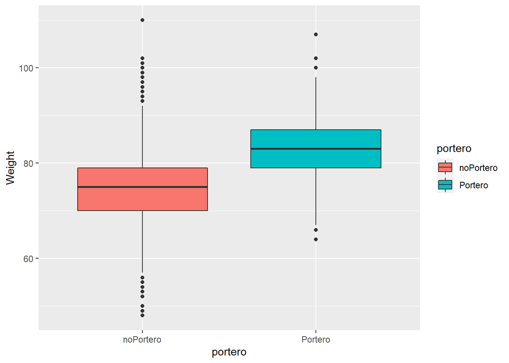

```r
fifaNet$portero <- as.factor(ifelse(fifaNet$Club_Position == "GK", "Portero", "noPortero"))

ggplot(data = fifaNet, aes(x = portero, y = Weight, fill=portero)) + geom_boxplot() + theme(legend.position="right")
```

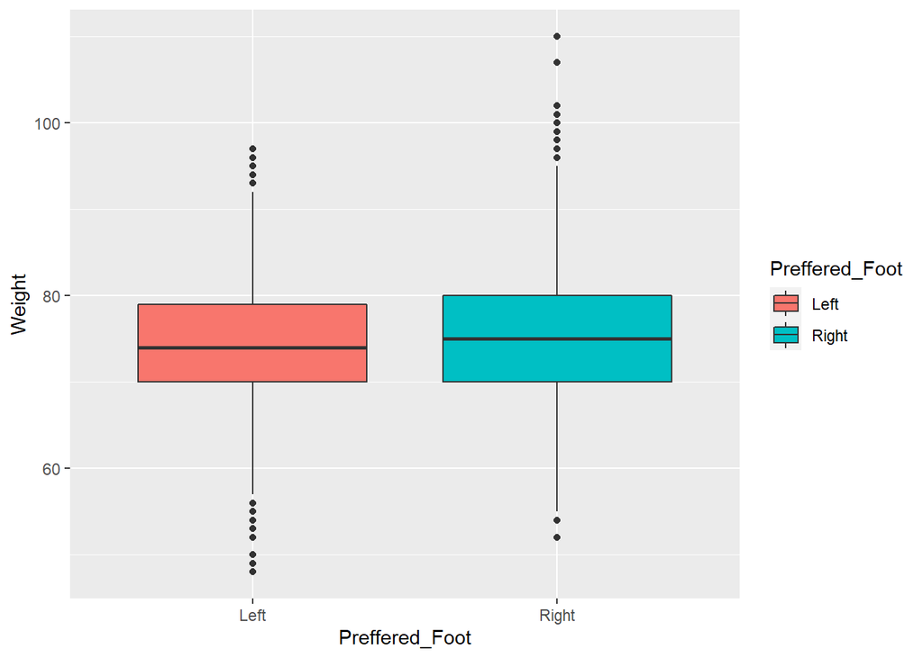

```r
ggplot(data = fifaNet, aes(x = Preffered_Foot, y = Weight, fill=Preffered_Foot)) + geom_boxplot() + theme(legend.position="right")
```

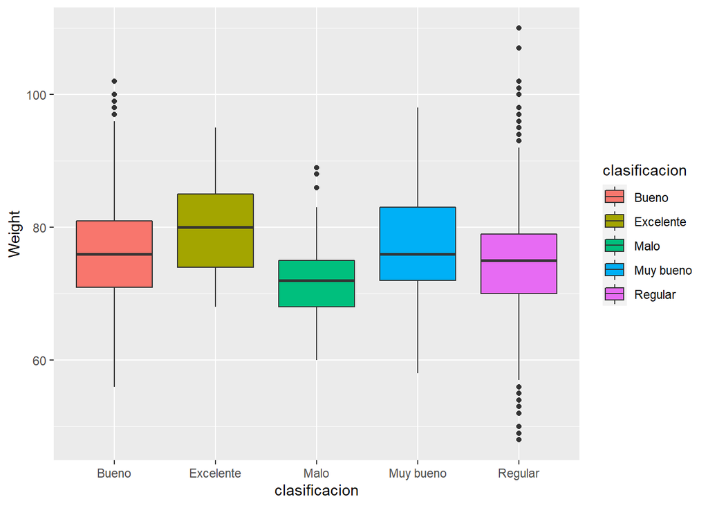

```r
ggplot(data = fifaNet, aes(x = clasificacion, y = Weight, fill=clasificacion)) + geom_boxplot() + theme(legend.position="right")
```

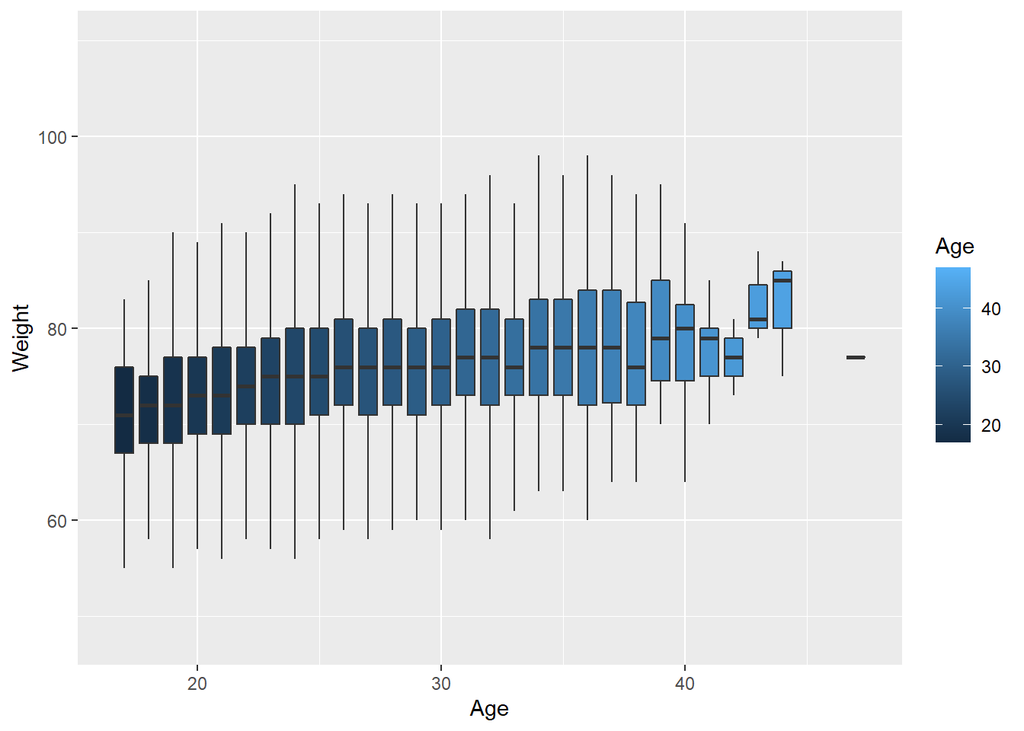

```r
ggplot(data = fifaNet, aes(x=Age, y=Weight, group=Age, fill=Age)) + geom_boxplot(notch=FALSE, outlier.shape=NA)
```

De aquí podemos obtener varias conclusiones curiosas:

- Los porteros tienen un peso más alto que el resto de jugadores.
- El pie con el que prefieren lanzar los jugadores no revela una gran diferencia en cuanto al peso de éstos.
- Los jugadores que tienen una mejor calificación (“Excelente” y “Muy bueno”) tienen un peso más elevado que el resto, siendo los calificados como “Malo” los más ligeros.
- En cuanto a la edad, vemos que según van envejeciendo los jugadores aumentan de peso.

## 2.4 Comprobación de normalidad

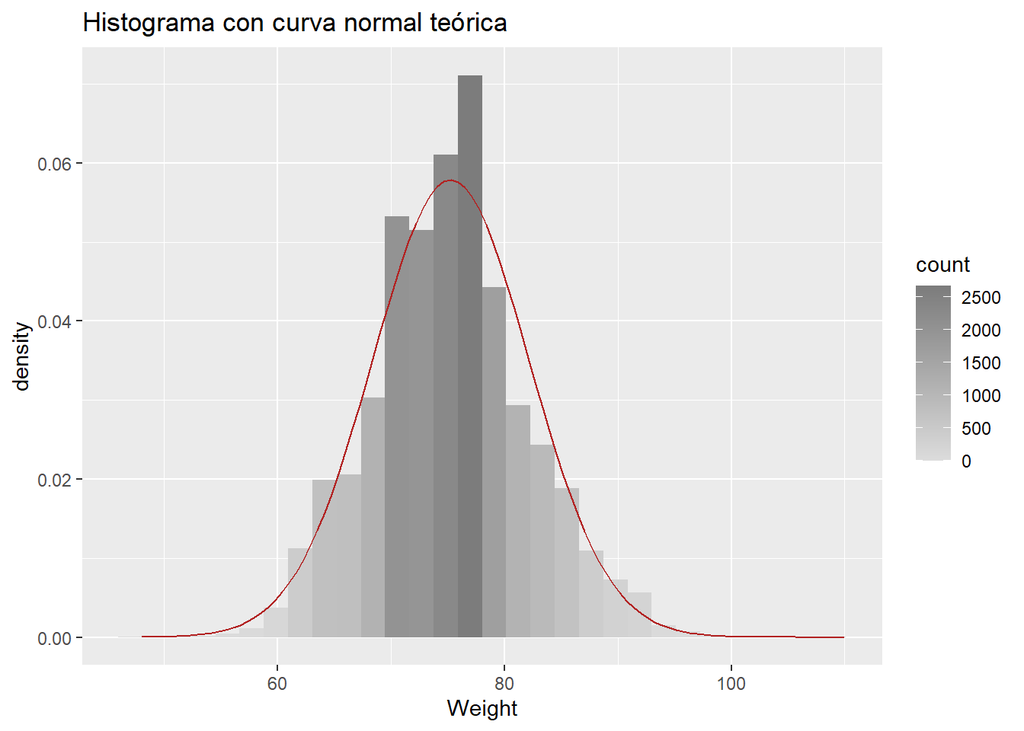

```r
ggplot(data = fifaNet, aes(x = Weight)) +
  geom_histogram(aes(y = ..density.., fill = ..count..)) +
  scale_fill_gradient(low = "#DCDCDC", high = "#7C7C7C") +
  stat_function(fun = dnorm, colour = "firebrick", args = list(mean = mean(fifaNet$Weight), sd = sd(fifaNet$Weight))) +
  ggtitle("Histograma con curva normal teórica")
```

Claramente vemos que podemos asumir que la variable Weight tiene una distribución normal.

# 3 Estadística inferencial

## 3.1 Intervalo de confianza de la media poblacional de la variable Weight

Procedemos al cálculo del intervalo de confianza de la variable Weight, para ello, creamos una función que nos permita hacer este cálculo con distintos vectores de datos.

```r
Int_conf <- function(vector) {
  desv <- sd(vector)                      # Calculamos la desviación tipica de la distribución
  t <- qt(0.05/2,length(vector))          # Para un nivel de confianza del 95%
  error_est <- desv/sqrt(length(vector))  # Calculamos el error estándar
  margen_error <- t * error_est           # Margen de error
  lim_inf <- mean(vector) + margen_error
  lim_sup <- mean(vector) - margen_error
  interval <- c(lim_inf,lim_sup)
  return(interval)
}
Int_conf(fifaNet$Weight)
```

```
## [1] 75.15113 75.35504
```

```r
#Intervalo de confianza de la variable Weight para los porteros.
Int_conf(fifaNet$Weight[fifaNet$portero == "Portero"])
```

```
## [1] 82.53728 83.47538
```

```r
#Intervalo de confianza de la variable Weight para los jugadores de campo.
Int_conf(fifaNet$Weight[fifaNet$portero == "noPortero"])
```

```
## [1] 74.86233 75.06583
```

## 3.2 Contraste de hipótesis para la diferencia de medias

Para ello, aplicaremos el test de contrastes de dos muestras independientes sobre la media con varianzas desconocidas:

$$\left\{
\begin{array}{ll}
H_{0}: & \mu_1=\mu_2\\
H_{1}: & \mu_1 >\mu_2 +5
\end{array}
\right.$$
Donde $\mu_1$ es la media de altura de los porteros y $\mu_2$ la media de altura de los jugadores de campo

Por tanto, aplicamos un test de hipótesis de dos muestras sobre la media. Aplicaremos la distribución t, dado que no se conoce la varianza de la población. Es necesario comprobar si podemos suponer varianzas iguales. Para ello, aplicamos el test var.test de R:

```r
GK <- fifaNet$Height[fifaNet$portero == "Portero"]
noGK <- fifaNet$Height[!fifaNet$portero == "noPortero"]

var.test(GK, noGK)
```

```
##
##  F test to compare two variances
##
## data:  GK and noGK
## F = 1, num df = 631, denom df = 631, p-value = 1
## alternative hypothesis: true ratio of variances is not equal to 1
## 95 percent confidence interval:
##  0.8553958 1.1690494
## sample estimates:
## ratio of variances
##                  1
```

```r
mean1 <- mean(GK)
mean2 <- mean(noGK)
n1 <- length(GK)
n2 <- length(noGK)
sd1 <- sd(GK)
sd2 <- sd(noGK)

Sb <- sqrt( sd1^2/n1 + sd2^2/n2 )
denom <- ( (sd1^2/n1)^2/(n1-1) + (sd2^2/n2)^2/(n2-1))
df <- ( (sd1^2/n1 + sd2^2/n2)^2 ) / denom

alfa <- (1-0.95)
t<- (mean1-mean2) / Sb
tcritical <- qt( alfa, df, lower.tail=FALSE )
pvalue<-pt( t, df, lower.tail=FALSE )
c(t,tcritical,pvalue,df)
```

```
## [1]    0.000000    1.646062    0.500000 1262.000000
```

```r
t.test( GK, noGK, var.equal=FALSE, alternative = "greater")
```

```
##
##  Welch Two Sample t-test
##
## data:  GK and noGK
## t = 0, df = 1262, p-value = 0.5
## alternative hypothesis: true difference in means is greater than 0
## 95 percent confidence interval:
##  -0.4221264        Inf
## sample estimates:
## mean of x mean of y
##   188.413   188.413
```

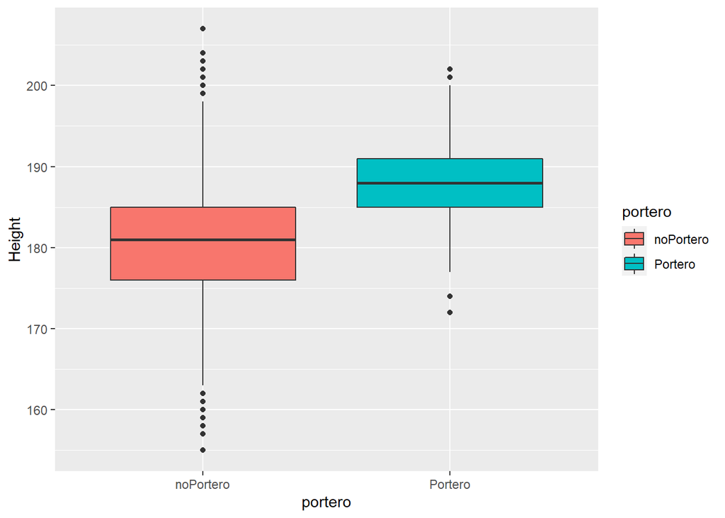

```r
ggplot(data = fifaNet, aes(x = portero, y = Height, fill=portero)) + geom_boxplot() + theme(legend.position="right")
```

# 4 Modelo de regresión lineal

Generaremos a continuación un modelo de regresión lineal múltiple con las variables explicativas: Age, portero, Weight, Preffered_Foot, Vision y Ball_Control y como variable dependiente el Rating de los jugadores. Estableciendo como referencia para las variables cualitativas portero y Preffered_Foot “Portero” y “Left” respectivamente.

```r
fifaNet$portero <- relevel(fifaNet$portero, ref="Portero")
fifaNet$Preffered_Foot <- relevel(fifaNet$Preffered_Foot, ref="Left")
regresionMult <- lm(Rating ~ Age + portero + Weight + Preffered_Foot + Vision + Ball_Control, data=fifaNet)
```

## 4.1 Interpretación del modelo

```r
summary(regresionMult)
```

```
##
## Call:
## lm(formula = Rating ~ Age + portero + Weight + Preffered_Foot +
##     Vision + Ball_Control, data = fifaNet)
##
## Residuals:
##      Min       1Q   Median       3Q      Max
## -22.0537  -3.3570  -0.2433   3.0596  26.0988
##
## Coefficients:
##                      Estimate Std. Error t value Pr(>|t|)
## (Intercept)         28.818004   0.561571   51.32   <2e-16 ***
## Age                  0.446879   0.008600   51.96   <2e-16 ***
## porteronoPortero    -9.353242   0.231161  -40.46   <2e-16 ***
## Weight               0.244425   0.006036   40.49   <2e-16 ***
## Preffered_FootRight -0.047315   0.089212   -0.53    0.596
## Vision               0.089804   0.003946   22.76   <2e-16 ***
## Ball_Control         0.205212   0.003698   55.50   <2e-16 ***
## ---
## Signif. codes:  0 '***' 0.001 '**' 0.01 '*' 0.05 '.' 0.1 ' ' 1
##
## Residual standard error: 4.96 on 17580 degrees of freedom
## Multiple R-squared:  0.5096, Adjusted R-squared:  0.5094
## F-statistic:  3045 on 6 and 17580 DF,  p-value: < 2.2e-16
```

Para interpretar el modelo generado, nos fijaremos en el valor $R^2$, que nos informa de la calidad del ajuste. En este caso, vemos que tenemos un 50.96%. Si nos fijamos en la significancia de cada una de las variables, vemos que salvo la variable que establece el pie de preferencia del jugador, el resto tienen una significancia parecida, sin embargo, vemos que esta variable tiene una significancia especialmente superior con un p-value=0.596.

## 4.2 Predicción

Aplicaremos ahora el modelo de regresión creado para predecir el rating de un jugador de campo con pie izquierdo preferido, con un peso de 70, edad de 24, control del balón de 80 y visión de 60.

```r
nuevoJugador <- data.frame(portero = "noPortero", Preffered_Foot = "Left", Weight = 70 , Age = 24, Ball_Control = 80, Vision = 60)
predict(regresionMult, nuevoJugador)
```

```
##        1
## 69.10481
```

Estimamos así que el rating para este jugador será de 69.10481.

# 5 Regresión logística

Se desea obtener un modelo predictivo basado en la regresión logística para predecir la probabilidad de jugar en la selección nacional en función de las variables: portero, Rating, Age y Work_Rate.

Para ello, crearemos una variable internacional que indique si el jugador es internacional tomando el valor 0 cuando el jugador no tiene dorsal en la selección y 1 cuando si lo tenga.

```r
fifaNet$internacional <- as.factor( ifelse( fifaNet$National_Position != '',1,0))
head(fifaNet$internacional,10)
```

```
##  [1] 1 1 1 1 1 1 1 1 0 1
## Levels: 0 1
```

```r
modelo_logistico <- glm(internacional ~ portero + Rating + Age + Work_Rate, data = fifaNet, family = "binomial")
summary(modelo_logistico)
```

```
##
## Call:
## glm(formula = internacional ~ portero + Rating + Age + Work_Rate,
##     family = "binomial", data = fifaNet)
##
## Deviance Residuals:
##     Min       1Q   Median       3Q      Max
## -1.6060  -0.3454  -0.2231  -0.1357   3.6023
##
## Coefficients:
##                            Estimate Std. Error z value Pr(>|z|)
## (Intercept)              -14.840544   0.506232 -29.316  < 2e-16 ***
## porteronoPortero          -0.471770   0.146771  -3.214 0.001307 **
## Rating                     0.197794   0.005951  33.235  < 2e-16 ***
## Age                       -0.028663   0.008623  -3.324 0.000888 ***
## Work_RateHigh / Low       -0.437268   0.189782  -2.304 0.021220 *
## Work_RateHigh / Medium    -0.493416   0.132552  -3.722 0.000197 ***
## Work_RateLow / High       -0.537016   0.244983  -2.192 0.028375 *
## Work_RateLow / Low        -1.398818   1.068024  -1.310 0.190289
## Work_RateLow / Medium     -0.556625   0.258108  -2.157 0.031040 *
## Work_RateMedium / High    -0.435759   0.149203  -2.921 0.003494 **
## Work_RateMedium / Low     -0.857744   0.202352  -4.239 2.25e-05 ***
## Work_RateMedium / Medium  -0.623227   0.125008  -4.985 6.18e-07 ***
## ---
## Signif. codes:  0 '***' 0.001 '**' 0.01 '*' 0.05 '.' 0.1 ' ' 1
##
## (Dispersion parameter for binomial family taken to be 1)
##
##     Null deviance: 8091.8  on 17586  degrees of freedom
## Residual deviance: 6447.9  on 17575  degrees of freedom
## AIC: 6471.9
##
## Number of Fisher Scoring iterations: 6
```

## 5.1 Matriz de confusión

Analizamos la precisión del modelo, comparando la predicción del modelo sobre los mismos datos del conjunto de datos. Asumiremos que la predicción del modelo es 1 (internacional) si la probabilidad del modelo de regresión logística es superior o igual a 0.5 y 0 en caso contrario.

```r
fifaNet$predicted <- predict(modelo_logistico, fifaNet, type = 'response')
fifaNet$predicted <- as.factor(ifelse(fifaNet$predicted > 0.5, 1, 0))

confusionMatrix(fifaNet$predicted, fifaNet$internacional, positive = "1")
```

```
## Confusion Matrix and Statistics
##
##           Reference
## Prediction     0     1
##          0 16469   977
##          1    43    98
##
##                Accuracy : 0.942
##                  95% CI : (0.9384, 0.9454)
##     No Information Rate : 0.9389
##     P-Value [Acc > NIR] : 0.04229
##
##                   Kappa : 0.1491
##
##  Mcnemar's Test P-Value : < 2e-16
##
##             Sensitivity : 0.091163
##             Specificity : 0.997396
##          Pos Pred Value : 0.695035
##          Neg Pred Value : 0.943999
##              Prevalence : 0.061125
##          Detection Rate : 0.005572
##    Detection Prevalence : 0.008017
##       Balanced Accuracy : 0.544279
##
##        'Positive' Class : 1
##
```

## 5.2 Interpretación

Como vemos, la matriz nos muestra que el modelo es muy bueno reconociendo los casos negativos, pero que por el contrario, a muchos jugadores nacionales no los clasifica como tal. La precisión media es de un 54.4% por este motivo.

## 5.3 Interpretación de la variable Work_Rate

```r
fifaNet$Work_Rate <- relevel(fifaNet$Work_Rate, ref='Medium / Medium')
modelo_logistico2 <- glm(internacional ~ portero + Rating + Age + Work_Rate, data = fifaNet, family = "binomial")
summary(modelo_logistico2)
```

```
##
## Call:
## glm(formula = internacional ~ portero + Rating + Age + Work_Rate,
##     family = "binomial", data = fifaNet)
##
## Deviance Residuals:
##     Min       1Q   Median       3Q      Max
## -1.6060  -0.3454  -0.2231  -0.1357   3.6023
##
## Coefficients:
##                          Estimate Std. Error z value Pr(>|z|)
## (Intercept)            -15.463771   0.474175 -32.612  < 2e-16 ***
## porteronoPortero        -0.471770   0.146771  -3.214 0.001307 **
## Rating                   0.197794   0.005951  33.235  < 2e-16 ***
## Age                     -0.028663   0.008623  -3.324 0.000888 ***
## Work_RateHigh / High     0.623227   0.125008   4.985 6.18e-07 ***
## Work_RateHigh / Low      0.185959   0.164009   1.134 0.256867
## Work_RateHigh / Medium   0.129811   0.093054   1.395 0.163014
## Work_RateLow / High      0.086211   0.225283   0.383 0.701958
## Work_RateLow / Low      -0.775591   1.064006  -0.729 0.466042
## Work_RateLow / Medium    0.066602   0.239100   0.279 0.780590
## Work_RateMedium / High   0.187468   0.115433   1.624 0.104365
## Work_RateMedium / Low   -0.234517   0.178577  -1.313 0.189098
## ---
## Signif. codes:  0 '***' 0.001 '**' 0.01 '*' 0.05 '.' 0.1 ' ' 1
##
## (Dispersion parameter for binomial family taken to be 1)
##
##     Null deviance: 8091.8  on 17586  degrees of freedom
## Residual deviance: 6447.9  on 17575  degrees of freedom
## AIC: 6471.9
##
## Number of Fisher Scoring iterations: 6
```

## 5.4 Predicción

```r
nuevoJugador <- data.frame(portero = "Portero", Age = 25, Rating = 95, Work_Rate="High / High")
predict(modelo_logistico2, nuevoJugador, type='response')
```

```
##         1
## 0.9620684
```

Así obtenemos una predicción de que un portero de 25 años, con un rating de 95 puntos y una clasificación de Work_Rate como High/High irá a la selección con una probabilidad del 96.20%.

# 6 Análisis de la varianza (ANOVA) de un factor

```r
summary(fifaNet$Age)
```

```
##    Min. 1st Qu.  Median    Mean 3rd Qu.    Max.
##   17.00   22.00   25.00   25.46   29.00   47.00
```

```r
fifaNet$AgeInt <- cut(fifaNet$Age, breaks = c(16,20,27,47), labels = c("Junior", "Middle","Senior"))
```

## 6.2 Hipótesis nula y alternativa

$$\left\{
\begin{array}{ll}
H_{0}: & \alpha_1=\alpha_2=···=\alpha_a=0\\
H_{1}: & \alpha_i ≠ \alpha_j &para &algún &i ≠ j
\end{array}
\right.$$

## 6.3 Modelo

```r
modelo_logistico3 <- lm(fifaNet$Rating ~ fifaNet$AgeInt)
anova = aov(modelo_logistico3)
summary(anova)
```

```
##                   Df Sum Sq Mean Sq F value Pr(>F)
## fifaNet$AgeInt     2 212801  106401    2795 <2e-16 ***
## Residuals      17584 669302      38
## ---
## Signif. codes:  0 '***' 0.001 '**' 0.01 '*' 0.05 '.' 0.1 ' ' 1
```

Claramente se aprecia que podemos descartar la hipótesis nula a favor de la hipótesis alternativa. Descartamos la hipótesis nula que afirmaba que todas las medias de la población (medias de los niveles delos factores) son iguales a favor de la hipótesis alternativa, que establece que al menos una de estas medias de la población es diferente.

## 6.4 Adecuación del modelo

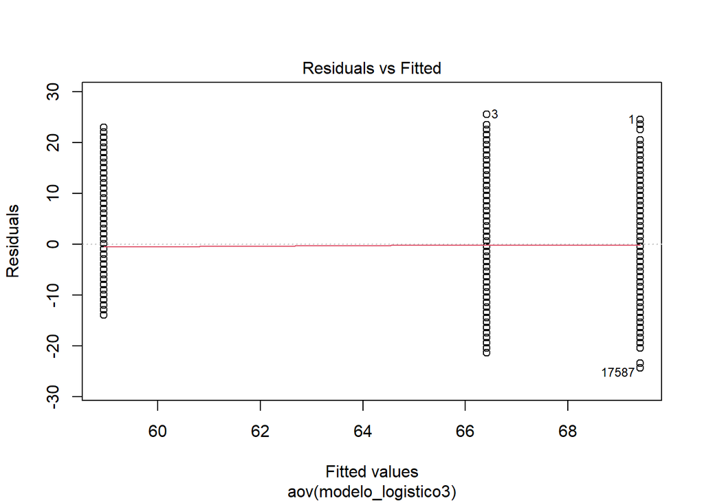

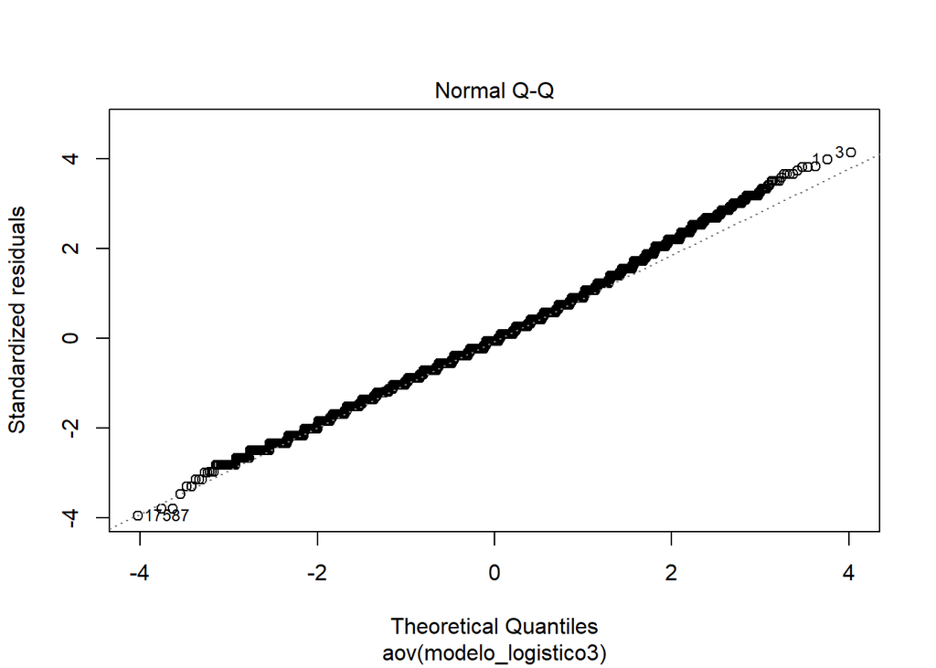

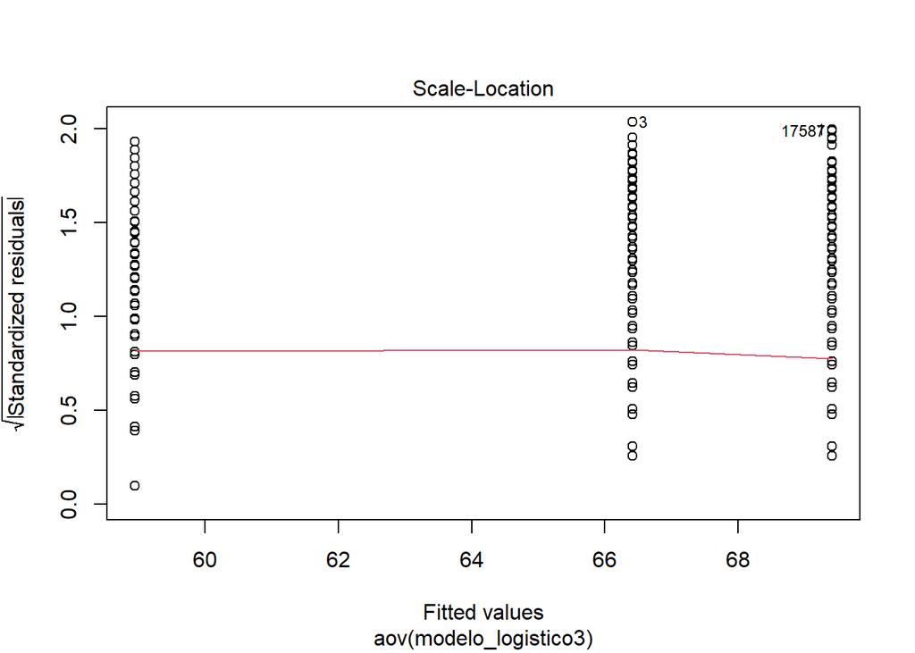

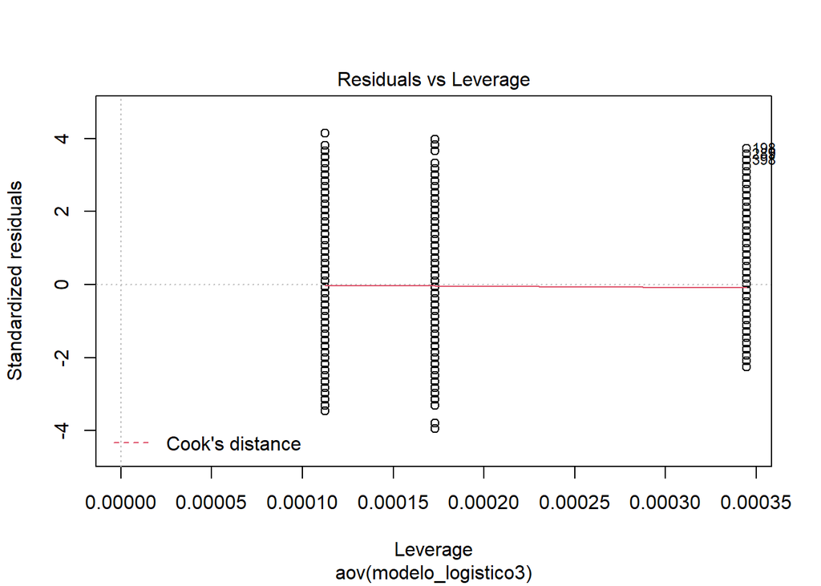

```r
plot(anova)
```

# 7 ANOVA Multifactorial

## 7.1 Análisis visual de los efectos principales y posibles interacciones

En primer lugar, haremos una visualización simple por separado de las variables en estudio.

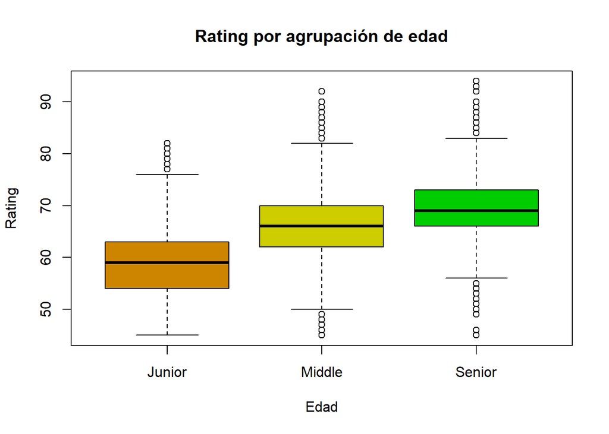

```r
plot(x = fifaNet$AgeInt, y = fifaNet$Rating, main = "Rating por agrupación de edad",
     xlab = "Edad", ylab = "Rating",
     col = c("orange3", "yellow3", "green3"))
```

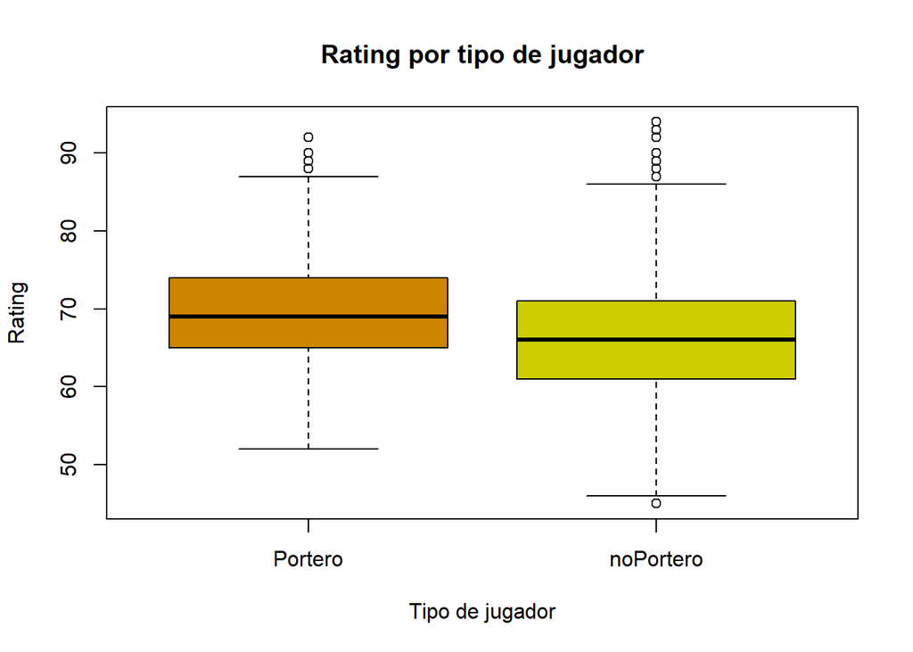

```r
plot(x = fifaNet$portero, y = fifaNet$Rating, main = "Rating por tipo de jugador",
     xlab = "Tipo de jugador", ylab = "Rating",
     col = c("orange3", "yellow3"))
```

A continuación, agrupamos por AgeInt y portero para calcular las medias en los distintos casos y representamos para su estudio.

```r
meanRating <- fifaNet %>% group_by(AgeInt,portero) %>% summarise(mean = mean(Rating))
meanRating
```

| AgeInt | portero | mean |
| --- | --- | --- |
| Junior | Portero | 65.66667 |
| Junior | noPortero | 58.90682 |
| Middle | Portero | 68.33333 |
| Middle | noPortero | 66.35966 |
| Senior | Portero | 70.98383 |
| Senior | noPortero | 69.30183 |

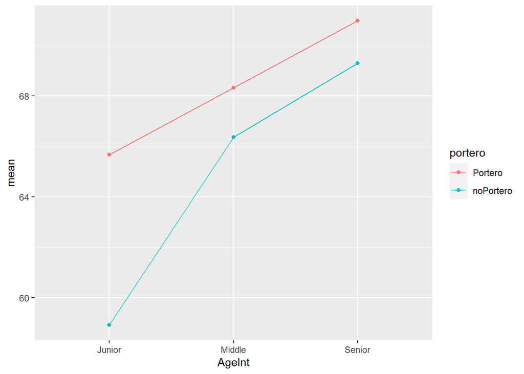

```r
ggplot(data=meanRating, aes(x=AgeInt, y=mean, group=portero)) +
  geom_line(aes(color=portero))+
  geom_point(aes(color=portero))
```

## 7.2 Cálculo del modelo

```r
anova2 = aov(lm(fifaNet$Rating ~ fifaNet$AgeInt + fifaNet$portero))
summary(anova2)
```

```
##                    Df Sum Sq Mean Sq F value   Pr(>F)
## fifaNet$AgeInt      2 212801  106401 2804.54  < 2e-16 ***
## fifaNet$portero     1   2226    2226   58.67 1.96e-14 ***
## Residuals       17583 667076      38
## ---
## Signif. codes:  0 '***' 0.001 '**' 0.01 '*' 0.05 '.' 0.1 ' ' 1
```

## 7.4 Adecuación del modelo

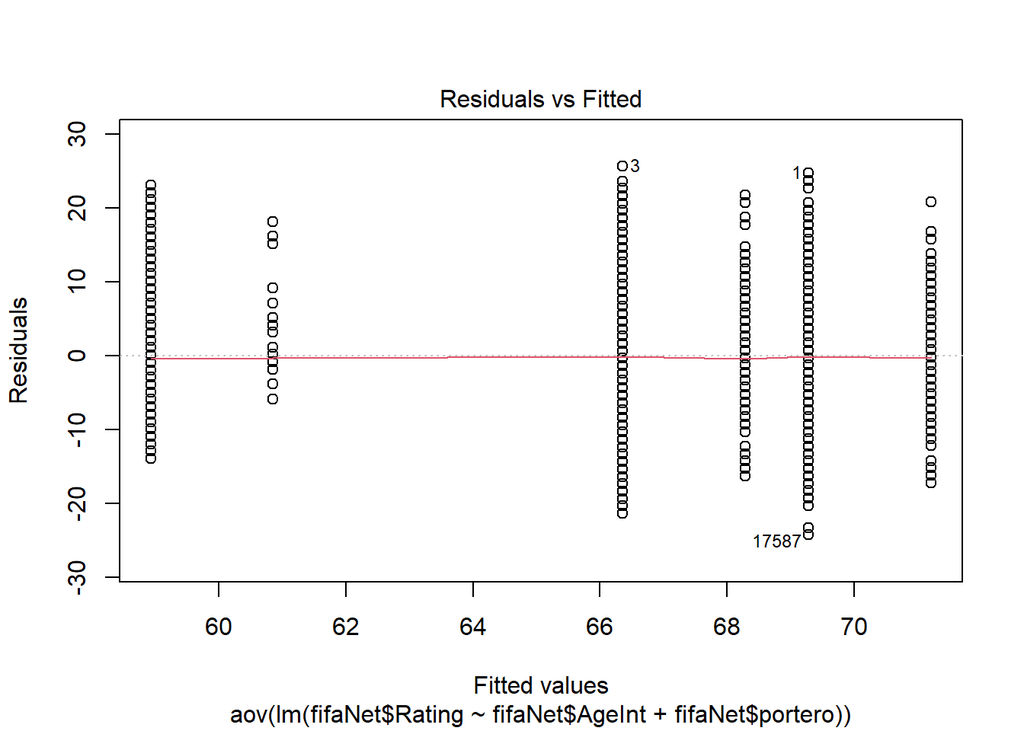

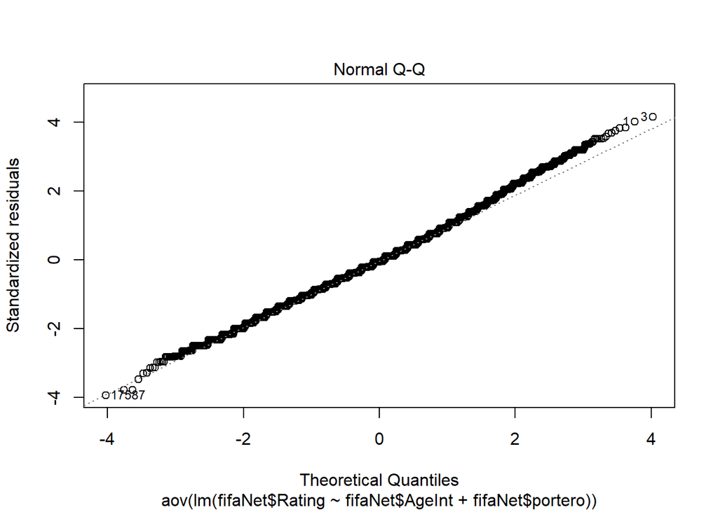

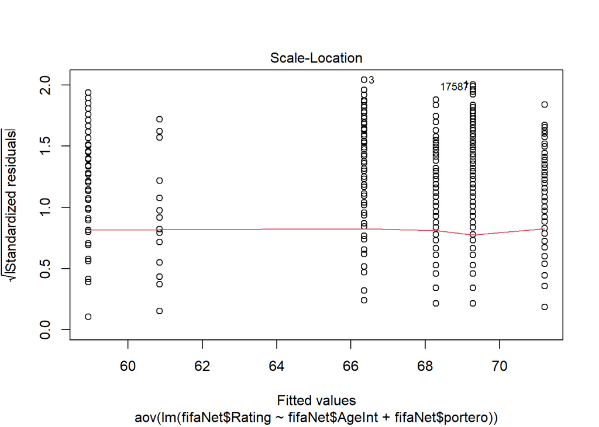

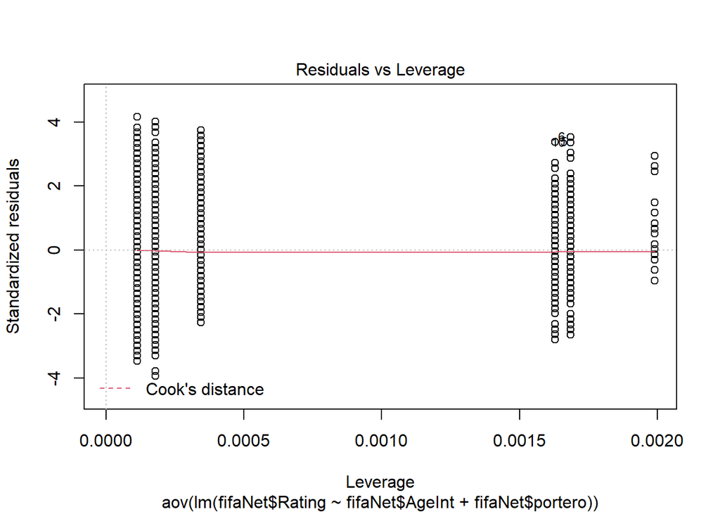

```r
plot(anova2)
```

# 8 Exportamos a CSV el dataset una vez analizado y modificado

```r
write.csv(fifaNet,"post_analisis.csv", row.names = TRUE)
```

# 9 Conclusiones

A lo largo de este estudio, hemos recogido varias conclusiones que resumimos a continuación:

Los porteros tienen un peso más alto que el resto de jugadores.

El pie con el que prefieren lanzar los jugadores no revela una gran diferencia en cuanto al peso de éstos.

Los jugadores que tienen una mejor calificación (“Excelente” y “Muy bueno”) tienen un peso más elevado que el resto, siendo los calificados como “Malo” los más ligeros.

En cuanto a la edad, vemos que según van envejeciendo los jugadores aumentan de peso.

Tras el estudio pertinente, se puede asumir que la variable Weight sigue una distribución normal.

En cuanto al ANOVA de un factor, descartamos la hipótesis nula que afirmaba que todas las medias de la población (medias de los niveles de los factores) son iguales a favor de la hipótesis alternativa, que establece que al menos una de estas medias de la población es diferente.